# Lista - AP2 - Identificação e Modelagem de Processos Estacionários

Jessé Peixoto de Freitas

02/07/2023

# Introdução

O presente trabalho tem como objetivo estudar o comportamento de alguns indicadores econômicos, como IPCA, e financeiros e avaliar suas séries temporais. Os modelo de séries temporais considerados serão AR - Autoregressivos, MA - Média móvel e ARMA - Autoregressivos de Média móvel, assim como suas respectivas Funções de Autocorrelação - FAC (*em inglês ACF - autocorrelation function*) e Autocorrelação Parcial (*em inglês PACF - Partial autocorrelation function*). Serão usados alguns testes de validação como Ljung-Box que avalia a autocorrelação do resíduos como suas defasagens. O Objetivo é verificar se a série apresenta Estacionariedade e apartir disso determina modelo e suas estimativas. O software ultilizado será o R/RStudio e os pacotes utilizados seram apresentados ao longo do texto.

### Questão 1:

Calcule as FAC e FACP (5 primeiros valores) para os processos estacionários a seguir:

1. $Y_t = \varepsilon _t + \theta \varepsilon_{t-1}; \theta = -0,5$
2. $(1 - \phi L )Y_t = \varepsilon _t; \phi = -0,9$
3. $(1 - \phi L )Y_t = \varepsilon _t + \theta \varepsilon_{t-1} ; \phi = -0,9 ; \theta = -0,5$

### Questão 2:

Obtenha as Séries do IPCA (IBGE - Instituto Brasileiro de Geografia e Estatística), Saldo de Crédito Total (BCB - Banco Central do Brasil), Retornos do Ibovespa e o preço de um ativo presente na B3 à sua escolha. (Todas mensais, de 01/2015 a 12/2022). Então, para cada série:

Fontes utilizadas:

- Fonte IBGE: [ibge.gov.br/](https://www.ibge.gov.br/estatisticas/economicas/precos-e-custos/9256-indice-nacional-de-precos-ao-consumidor-amplo.html?=&t=series-historicas)
- Fonte BCB: [bcb.gov.br/](https://www3.bcb.gov.br/sgspub/consultarvalores/consultarValoresSeries.do?method=consultarValores)
- Fonte IBOVESPA: [br.financas.yahoo.com/quote/%5EBVSP](https://br.financas.yahoo.com/quote/%5EBVSP/history?period1=1420070400&period2=1672444800&interval=1mo&filter=history&frequency=1mo&includeAdjustedClose=true)
- Fonte AAPL: [br.financas.yahoo.com/quote/AAPL](https://br.financas.yahoo.com/quote/AAPL/history?period1=1420070400&period2=1672444800&interval=1mo&filter=history&frequency=1mo&includeAdjustedClose=true)

Definindo as Séries temporais:

Pacotes utilizados:

```r
require(forecast)
require(ggplot2)
require(readr)
```

Visualizando as Séries:

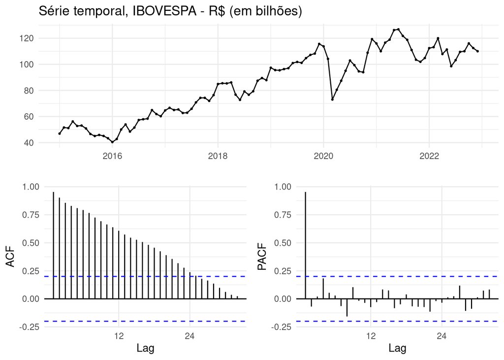

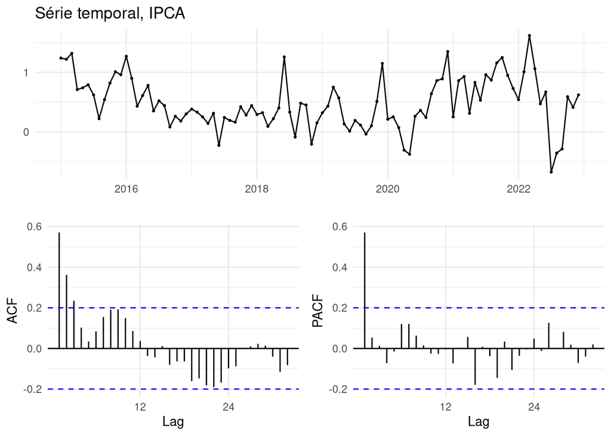

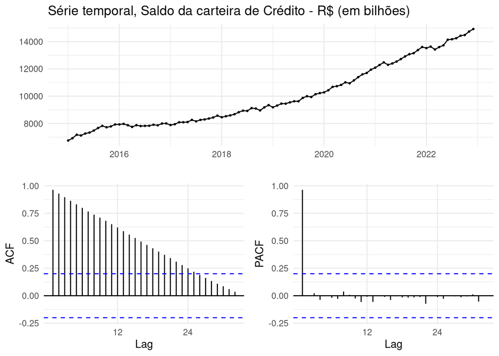

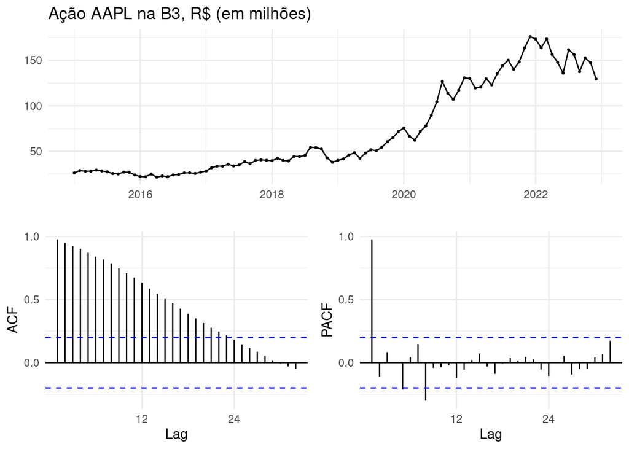

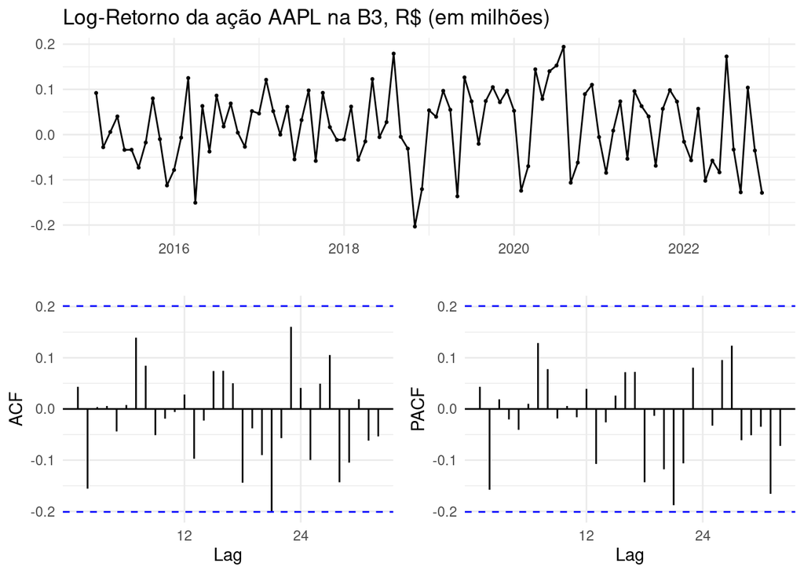

1. Realize os testes de identificação, assim como os de Critério de Informação e Diagnóstico de Resíduos.
2. Plote os gráficos de FAC e FACP.
3. Estime os coeficientes e apresente os modelos. (Utilize software apropriado)
4. O preço do ativo pode ser modelado por um processo estacionário? Se não, justifique e verifique se o retorno desse ativo é um processo estacionário.

### Questão 3:

Utilizando as séries disponibilizadas no arquivo “AP2.xlsx”, faça para cada uma das séries o que se pede:

1. Realize os testes de identificação, assim como os de Critério de Informação e Diagnóstico de Resíduos.
2. Plote os gráficos de FAC e FACP.
3. Estime os coeficientes e apresente os modelos. (Utilize software apropriado)